# Week 3

Hintz A and Gross Y.

2026-08-25

# Review exercises 1

1. Create a vector `n_rates` with the values 0, 40, 80, 120, 160 (kg N/ha).
2. Create a data frame with three columns: `plot` (1 to 5), `n_rate` (`n_rates` above), and `yield` (make up five plausible wheat yield values).
3. Write a function `kg_to_lb` that converts kilograms to pounds (1 kg = 2.2046 lb) and test it on your `yield` column.
4. Write a `for` loop that prints “Plot *X* received *Y* kg N/ha” for each row of your data frame.
5. Write a function `soil_ph()` that takes a single soil pH value as input and, using if/else, returns “Acidic” if the pH is below 7, and “Alkaline” if it’s above 7.

# Review exercises 2

The exercises are based on the data `yield.xlsx`, so first read the file and save it in the object `df`.

```r
#install.packages("readxl")
library(tidyverse)
library(readxl)
df <- read_xlsx("yield.xlsx")
```

1. Verify how many observations and variables are in the dataset and what are the categories of the variables.
2. Select just the column `location`, `plot`, `block`, `trt`, `system`, `wheat_yield_bu_acre_13.5`, `soy_yield_bu_acre_13`
3. Rename the variables that contain the wheat and soybean yield.
4. Verify if there are any NAs in the dataset.
5. Filter only the SW system and calculate the mean wheat yield for each location.
6. Calculate the mean and standard deviation for each system for wheat and soybean yield.

# New exercise

1. Create a new variable called yield_class that classifies the wheat yield as “High” if the yield is greater than or equal to 60 bu/ac and “Low” otherwise.
2. Create a function check_negative() that receives a yield variable and verifies if there are any negative values. If negative values are found, return a warning message; otherwise, return a message indicating that the data are valid.

Tip: Use the function any() to check whether at least one value in a logical condition is TRUE. For example, any(x < 0) returns TRUE if at least one value of x is negative.

# ggplot

`ggplot2` is a package used to create graphs in R.  
The basic idea is to start with a dataset and then add different layers to build the plot.

```r
dat_cb <- read_xlsx("crop_biomass_2025.xlsx")
```

## ggplot(): start a ggplot object

The `ggplot()` function initializes a plot.  
By itself, it creates an empty plotting object.

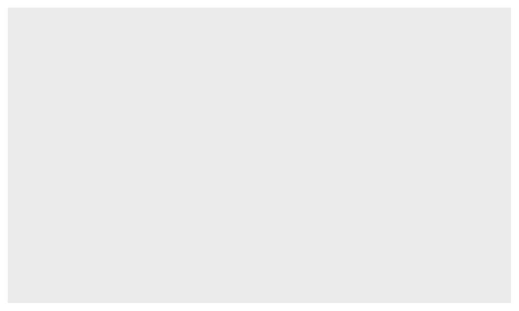

```r
ggplot()
```

Usually, we provide the dataset inside `ggplot()` and use `aes()` to define which variables will be represented in the graph.

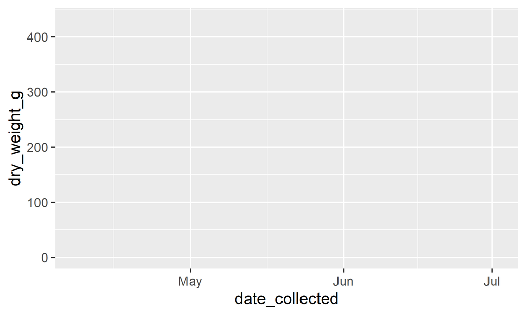

```r
dat_cb |>
  ggplot(aes(x = date_collected, y = dry_weight_g))
```

## Add layers

Plots in `ggplot2` are constructed by adding layers using `+`.

Most graphical layers are functions that start with `geom_...()`.

The visual properties of the plot are specified using the `aes()` function.

- `x` and `y` define the variables displayed on the axes.
- `color` controls the color of points or lines.
- `fill` controls the fill color of objects.
- `shape` controls the shape of points.
- `size` controls the size of graphical elements.

### geom_point()

`geom_point()` creates a scatter plot.

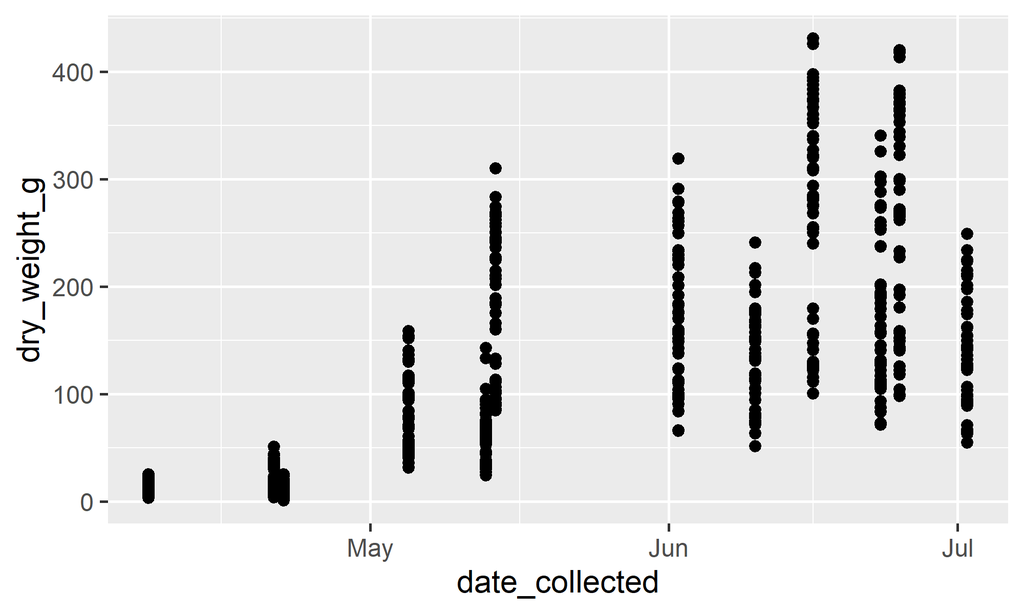

```r
dat_cb |>
  ggplot(aes(x = date_collected, y = dry_weight_g)) +
  geom_point()
```

### geom_histogram()

`geom_histogram()` shows the distribution of a continuous variable by dividing the observations into intervals called bins.

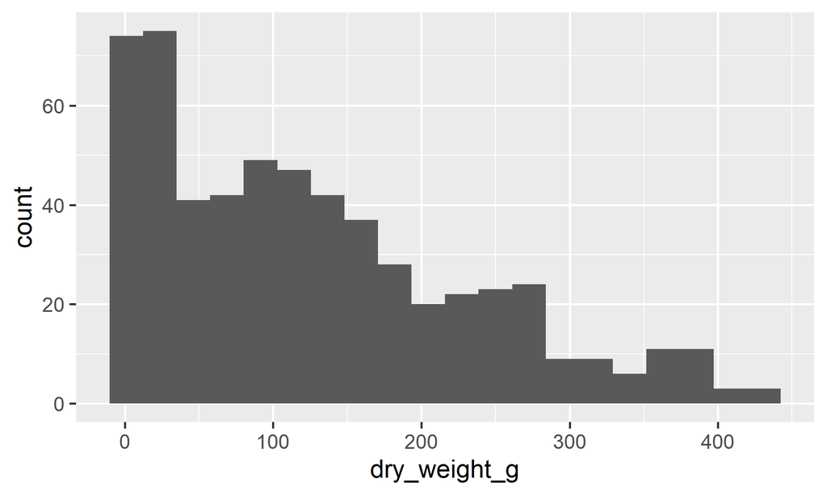

```r
dat_cb |>
  ggplot(aes(x = dry_weight_g)) +
  geom_histogram(bins = 20)
```

### geom_boxplot()

`geom_boxplot()` is useful for comparing the distribution of a continuous variable among different groups.

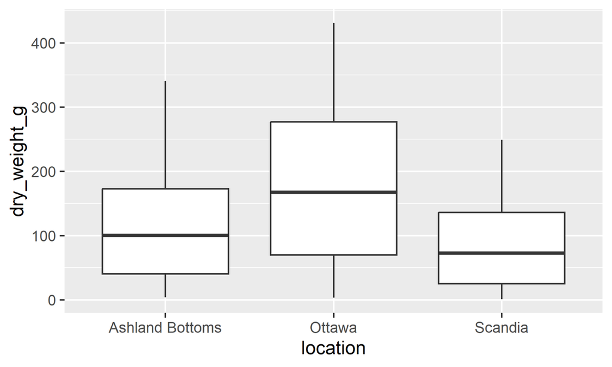

```r
dat_cb |>
  ggplot(aes(x = location, y = dry_weight_g)) +
  geom_boxplot()
```

## Adjust your aesthetics

Aesthetics can be used to represent additional variables in the graph.

For example, we can use color to represent `location` and shape to represent `sampling`.

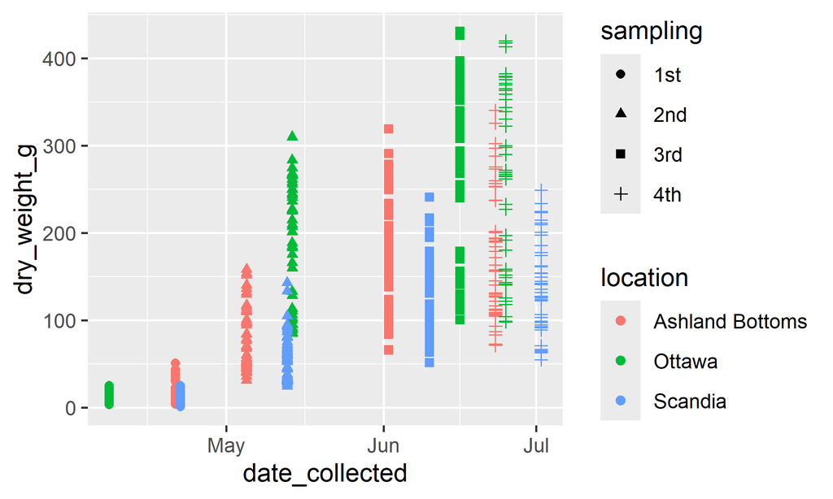

```r
dat_cb |>
  ggplot(aes(x = date_collected, y = dry_weight_g, color = location, shape = sampling)) +
  geom_point()
```

When a variable is written inside `aes()`, `ggplot2` creates a graphical representation of that variable and usually creates a legend automatically.

We can also define a visual property without mapping it to a variable.

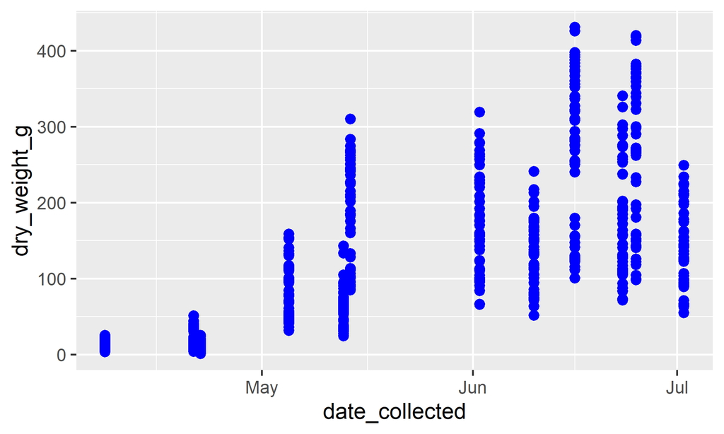

```r
dat_cb |>
  ggplot(aes(x = date_collected, y = dry_weight_g)) +
  geom_point(color = "blue", size = 2)
```

Here, all points have the same color and size because `color` and `size` are outside `aes()`.

## scale_…()

The `scale_...()` functions are used to control how variables are represented in the graph.

They can be used to modify colors, shapes, axis values, breaks, labels, and legends.

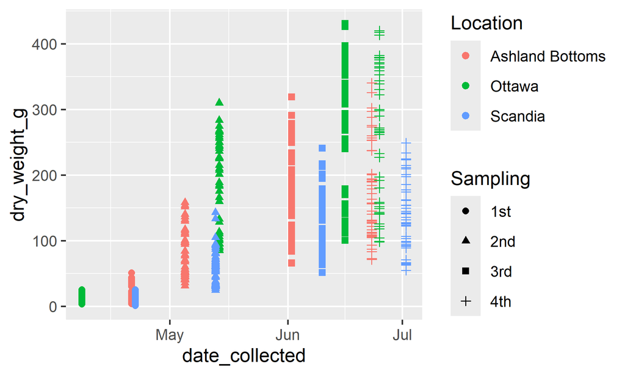

```r
dat_cb |>
  ggplot(aes(x = date_collected, y = dry_weight_g, color = location, shape = sampling)) +
  geom_point() +
  scale_color_discrete(name = "Location") +
  scale_shape_discrete(name = "Sampling")
```

Scale color and shape

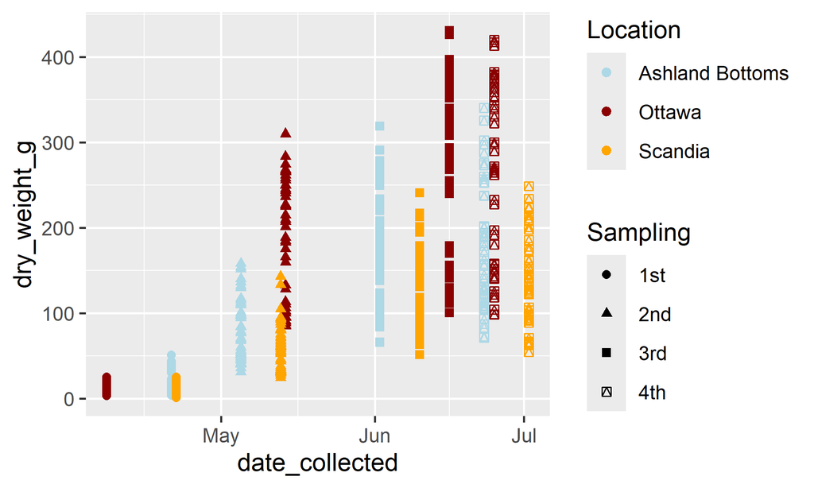

```r
dat_cb |>
  ggplot(aes(x = date_collected, y = dry_weight_g, color = location, shape = sampling)) +
  geom_point() +
  scale_color_manual(values = c("lightblue", "darkred", "orange"), name = "Location") +
  scale_shape_manual(values = c(16, 17, 15, 14), name = "Sampling")
```

We can also control the values displayed on continuous axes.

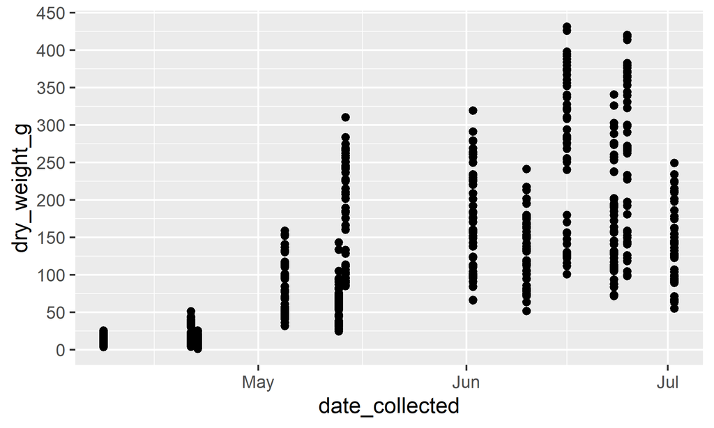

```r
dat_cb |>
  ggplot(aes(x = date_collected, y = dry_weight_g)) +
  geom_point() +
  scale_y_continuous(breaks = seq(0, 450, 50))
```

Because `date_collected` is a date variable, we can control how dates appear on the x-axis using `scale_x_date()`.

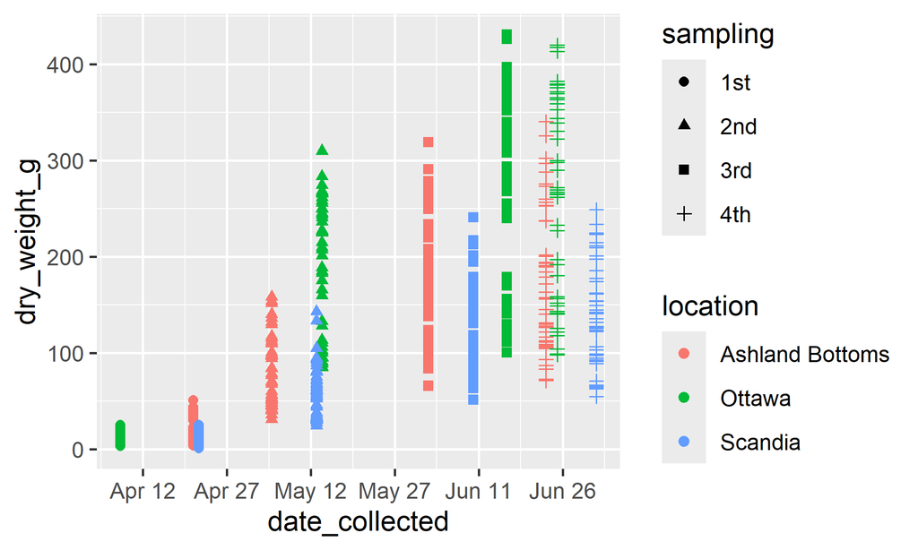

```r
dat_cb |>
  ggplot(aes(x = date_collected, y = dry_weight_g, color = location, shape = sampling)) +
  geom_point() +
  scale_x_date(date_breaks = "15 days", date_labels = "%b %d")
```

## coord_cartesian()

`coord_cartesian()` changes the portion of the graph that is displayed without removing observations from the dataset.

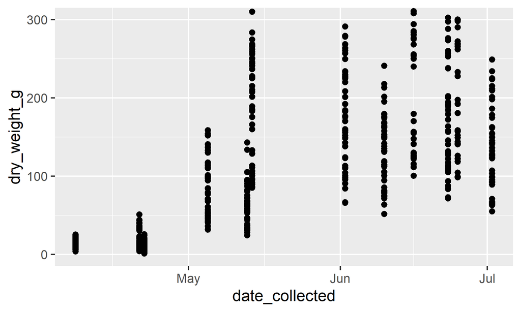

```r
dat_cb |>
  ggplot(aes(x = date_collected, y = dry_weight_g)) +
  geom_point() +
  coord_cartesian(ylim = c(0, 300))
```

## labs()

The `labs()` function is used to modify axis labels, titles, subtitles, captions, and legend titles.

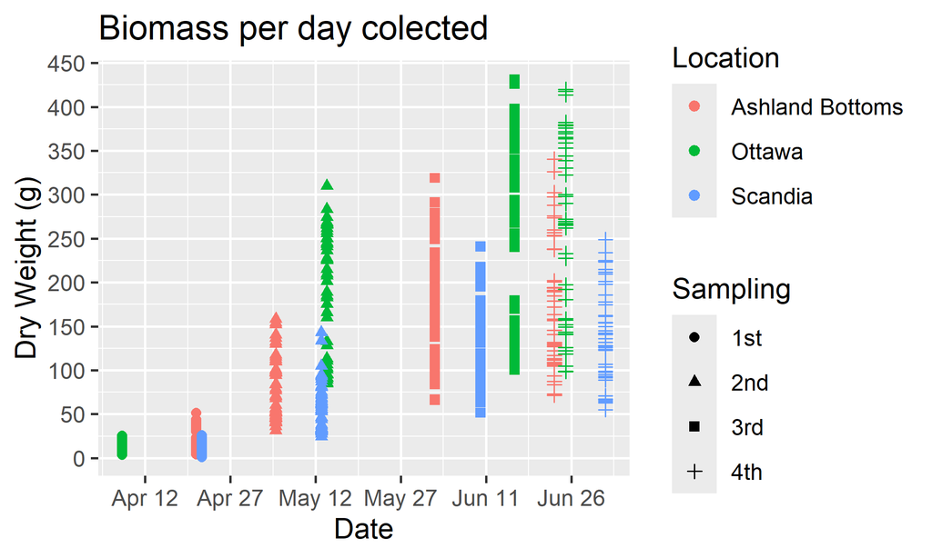

```r
dat_cb |>
  ggplot(aes(x = date_collected, y = dry_weight_g,
             color = location, shape = sampling)) +
  geom_point() +
  scale_y_continuous(breaks = seq(0, 450, 50)) +
  scale_x_date(date_breaks = "15 days", date_labels = "%b %d") +
  labs(
    x = "Date",
    y = "Dry Weight (g)",
    title = "Biomass per day colected",
    color = "Location",
    shape = "Sampling"
  )
```

## facet()

Faceting splits a graph into multiple panels according to a categorical variable.

`facet_wrap()` is useful when we want to create one plot for each level of a variable.

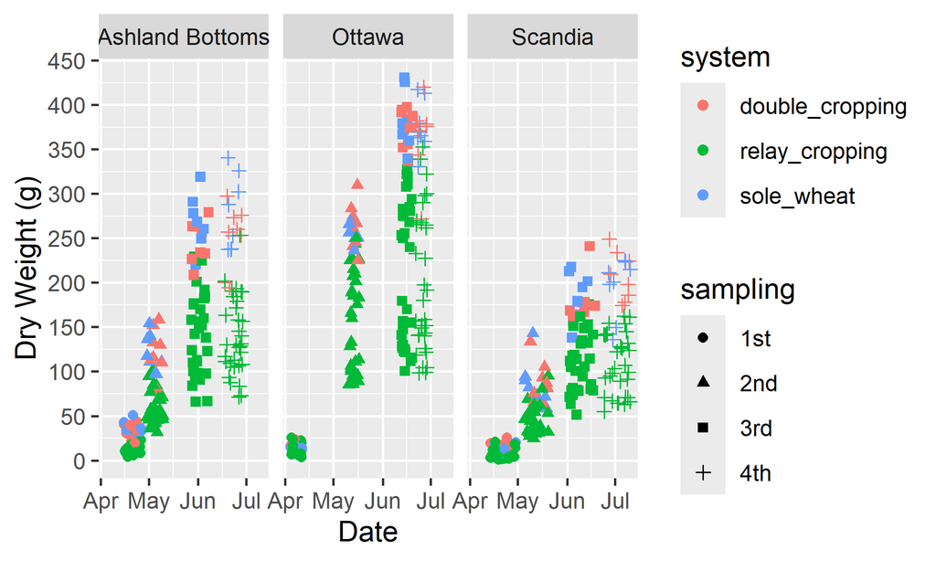

```r
dat_cb |>
  ggplot(aes(x = date_collected, y = dry_weight_g, color = system, shape = sampling)) +
  geom_jitter() +
  facet_wrap(~location) +
  scale_y_continuous(breaks = seq(0,450,50)) +
  scale_x_date(date_breaks = "1 month", date_labels = "%b") +
  labs(x = "Date", y = "Dry Weight (g)")
```

## Themes

Themes control the appearance of the graph, including the background, grid lines, axis text, and other non-data elements.

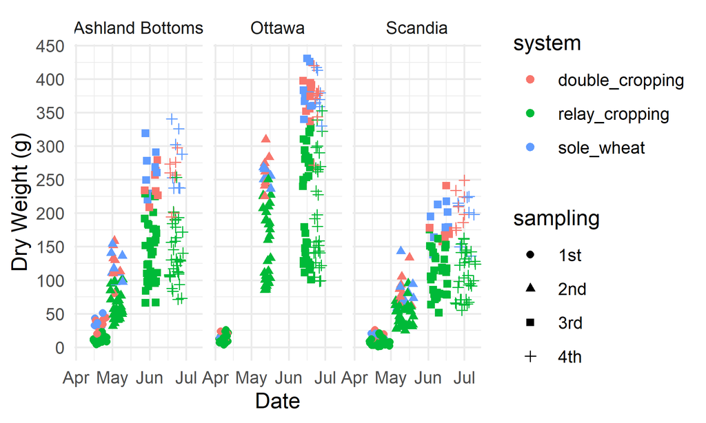

```r
dat_cb |>
  ggplot(aes(x = date_collected, y = dry_weight_g, color = system, shape = sampling)) +
  facet_wrap(~location) +
  geom_jitter() +
  scale_y_continuous(breaks = seq(0,450,50)) +
  scale_x_date(date_breaks = "1 month", date_labels = "%b") +
  labs(x = "Date", y = "Dry Weight (g)") +
  theme_minimal()
```

Some commonly used themes are:

```r
theme_minimal()
theme_classic()
theme_bw()
theme_dark()
```

## geom_tile()

`geom_tile()` creates rectangles arranged according to x and y coordinates.  
It is useful for creating heatmaps, field maps, and experimental layout diagrams.

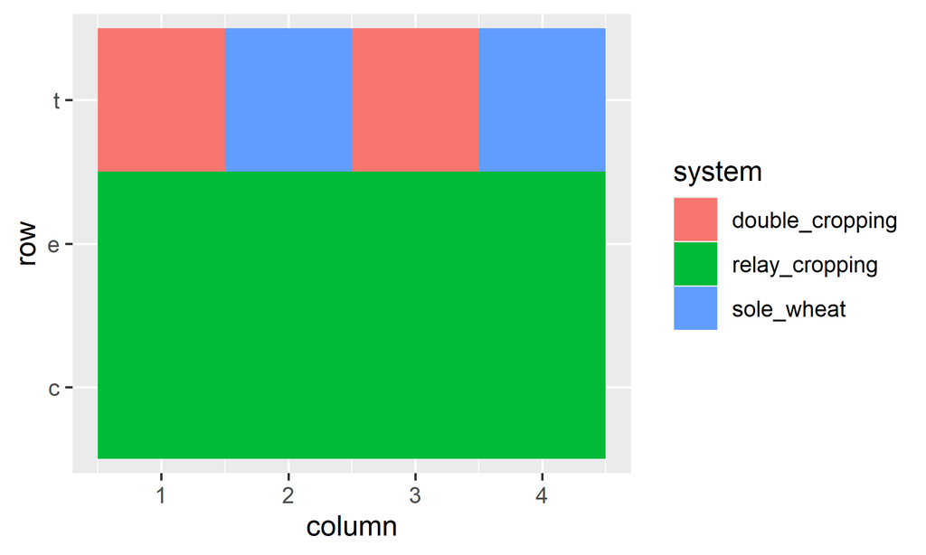

```r
dat_plot <- dat_cb |>
  mutate(
    column = as.numeric(substr(plot, 1, 1)),
    plot = as.factor(plot)
  ) |>
  distinct(plot, row, .keep_all = TRUE) |>
  select(plot, row, system, column)

dat_plot |>
  ggplot(aes(x = column, y = row, fill = system)) +
  geom_tile()
```

We can improve the visualization by adding borders and labels:

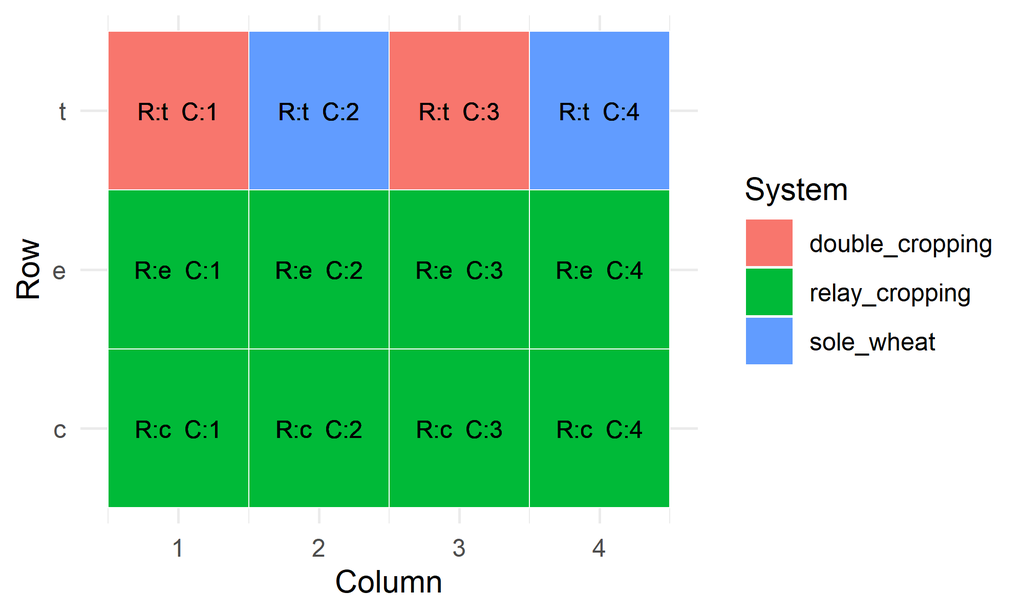

```r
dat_plot |>
  ggplot(aes(x = column, y = row, fill = system)) +
  geom_tile(color = "white") +
  geom_text(aes(label = paste0("R:", row, "  C:", column)), size = 3) +
  labs(x = "Column", y = "Row", fill = "System") +
  theme_minimal()
```